# PA1

Wei Jiang

2023-12-26

```r
knitr::opts_chunk$set(echo = TRUE, warning = FALSE)
```

**1. Load the data.**

```r
library(dplyr)
```

```r
library(ggplot2)
# load data and transfer date from char to Date
raw <- read.csv("/Users/weijiang/Downloads/activity.csv")
df <- raw
```

**2.Process/transform the data (if necessary) into a format suitable for your analysis.**

```r
df$date <- as.Date(df$date, format= "%Y-%m-%d")
df <- df %>% mutate(df, day = weekdays(df$date))
```

**3.Make a histogram of the total number of steps taken each day.**

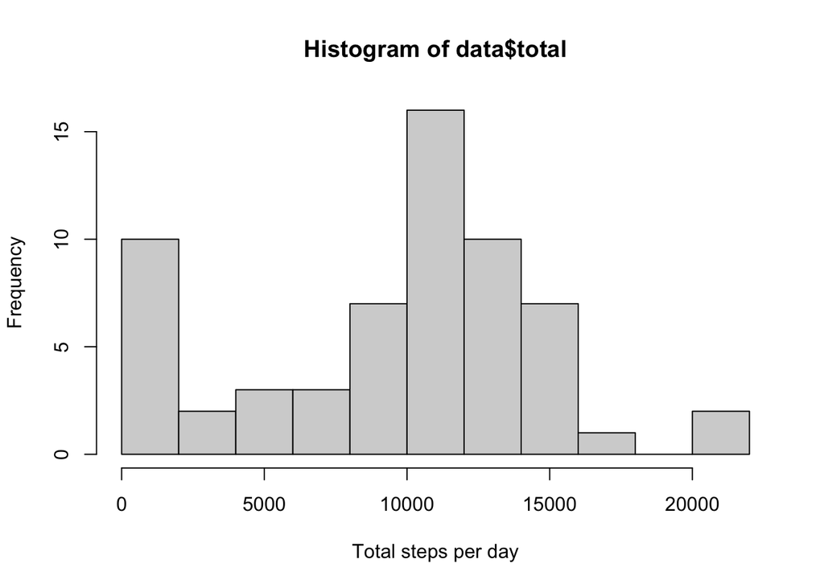

```r
# Calculate and report the mean and median total number of steps taken per day
data <- df %>% group_by(date) %>% summarise(total=sum(steps,na.rm = TRUE))
Mean <- as.integer(mean(data$total, na.rm = TRUE))
Median  <- median(data$total, na.rm = TRUE)
hist(data$total, breaks=9, xlab="Total steps per day")
```

```r
print(Mean)
```

```
## [1] 9354
```

```r
print(Median)
```

```
## [1] 10395
```

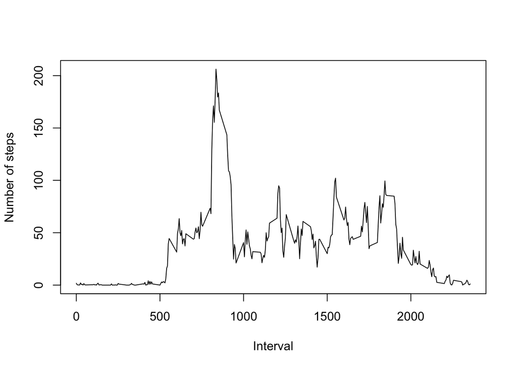

```r
# 5 minutes interval plot  the average number of steps
data <- df %>% group_by(interval) %>% summarise(Mean=mean(steps, na.rm=TRUE))
plot(x = data$interval, y = data$Mean, type = "l", ylab = "Number of steps", xlab = "Interval")
```

```r
# max steps of interval

max_indexes <- which.max(data$Mean)
# print interval with the max steps
print(data$interval[max_indexes])
```

```
## [1] 835
```

```r
# the max steps
print(data$Mean[max_indexes])
```

```
## [1] 206.1698
```

### Imputing missing values.

**1.Calculate and report the total number of missing values in the dataset (i.e. the total number of rows with NAs)..**

```r
n_miss <- sum(is.na(df)) # num of missing values

# print numbers of missing values
print(n_miss)
```

```
## [1] 2304
```

**2.Devise a strategy for filling in all of the missing values in the dataset. The strategy does not need to be sophisticated. For example, you could use the mean/median for that day, or the mean for that 5-minute interval, etc..**

```r
# replacing missing values by the median steps in that time frame of the day

# remove rows with "NA" in it
df_na_free <- na.omit(df)

# median steps of each time frame per day in whole null missing data
d1 <- df_na_free %>% mutate(day=weekdays(date))

d_med <- d1 %>% group_by(day, interval) %>% summarise(med_steps = median(steps))
```

[output not shown]

**3.Create a new dataset that is equal to the original dataset but with the missing data filled in..**

```r
# use the median steps of each time frame per day to replace the missing time frame date
# for example interval 0 in "2012-12-01" is "NA", "2012-12-01" is Monday
# replacing it with median steps at interval 0  on Monday

df_na_free <- df %>%
    left_join (d_med, by = c("interval","day")) %>% # left join the column with median steps to original df
    mutate(
        steps = ifelse(is.na(steps), d_med$med_steps, steps) # replacing "NA" by median steps
    ) %>%
    select(-med_steps)

head(df_na_free)
```

```
##   steps       date interval    day
## 1     0 2012-10-01        0 Monday
## 2     0 2012-10-01        5 Monday
## 3     0 2012-10-01       10 Monday
## 4     0 2012-10-01       15 Monday
## 5     0 2012-10-01       20 Monday
## 6     0 2012-10-01       25 Monday
```

**4.Make a histogram of the total number of steps taken each day and Calculate and report the mean and median total number of steps taken per day. Do these values differ from the estimates from the first part of the assignment? What is the impact of imputing missing data on the estimates of the total daily number of steps?..**

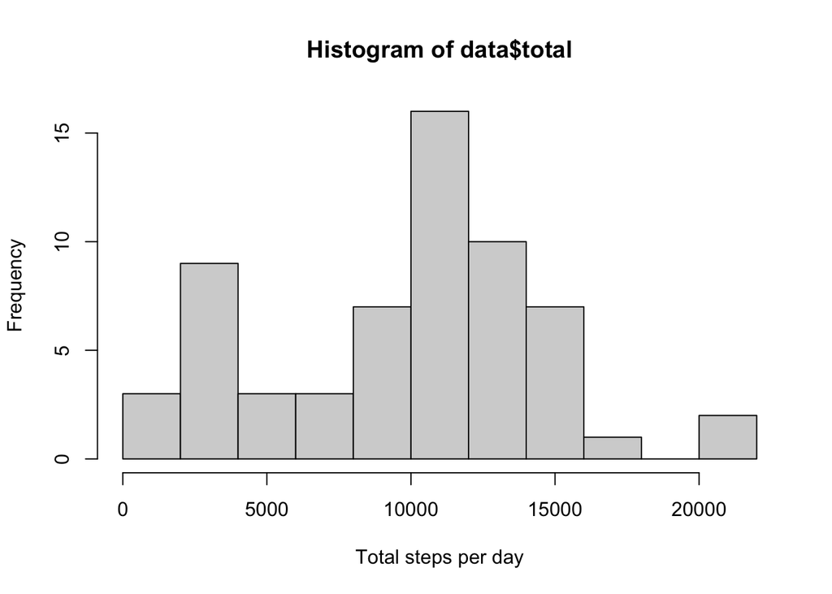

```r
data <- df_na_free %>% group_by(date) %>% summarise(total=sum(steps))
hist(data$total, breaks=9, xlab="Total steps per day")
```

```r
# Calculate and report the mean and median total number of steps taken per day
data <- df_na_free %>% group_by(date) %>% summarise(total=sum(steps))
Mean <- as.integer(mean(data$total, na.rm = TRUE))
Median  <- median(data$total, na.rm = TRUE)
# print Mean and median without missing value
cat ("Mean of daily steps is", Mean, "\n")
```

```
## Mean of daily steps is 9696
```

```r
cat ("Median of daily steps is", Median, "\n")
```

```
## Median of daily steps is 10395
```

### Are there differences in activity patterns between weekdays and weekends?..

** 1.Create a new factor variable in the dataset with two levels – “weekday” and “weekend” indicating whether a given date is a weekday or weekend day.**

```r
df_na_free <- df_na_free %>% mutate(day_type = ifelse(df_na_free$day %in% c("Saturday", "Sunday"), "weekend", "weekday"))
head(df_na_free)
```

```
##   steps       date interval    day day_type
## 1     0 2012-10-01        0 Monday  weekday
## 2     0 2012-10-01        5 Monday  weekday
## 3     0 2012-10-01       10 Monday  weekday
## 4     0 2012-10-01       15 Monday  weekday
## 5     0 2012-10-01       20 Monday  weekday
## 6     0 2012-10-01       25 Monday  weekday
```

```r
group_day_type <- df_na_free %>% group_by(interval, day_type) %>% summarise(ave=mean(steps))
```

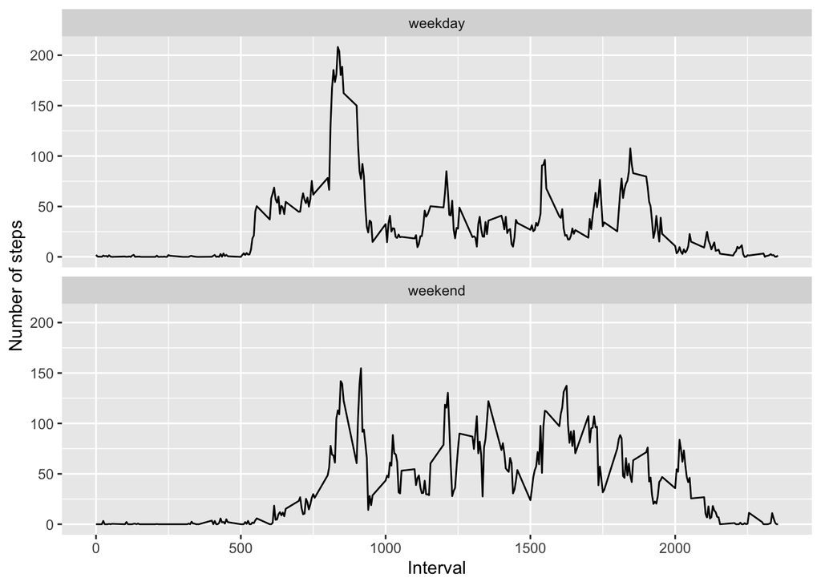

```r
ggplot(group_day_type,aes(x=interval,y=ave)) +
    geom_line() +
    facet_wrap(~ day_type, nrow=3, ncol=1) +
    labs(x="Interval", y="Number of steps")
```